# Week 5 Assignment

Shannon Edie

February 4, 2020

## Part I

First I imported the sequences CSV file that I just created using the Download.R script.

```r
# Import the dataset
seq.dat <- read.csv("Sequences.csv", stringsAsFactors=F)
```

Then, I created a code chunk that uses RegEx functions to get counts the number of each base pair (A, C, T, and G) in each of the three sequences. Because the assignment instructions hinted at using for loops and gsub(), I wrote this code out, which is fully functional and results in the same output as the code I actually used.

```r
# An inefficient way of doing it using regex functions

char.count <- data.frame("Name"=c(), "A"=c(), "C"=c(), "T"=c(), "G"=c())

# Loop through all three sequences
for (i in 1:3) {

  # Print the name of the sequence we're looking at
  print(seq.dat$Name[i])

  # Initialize a vector that we can save count totals to
  tot.vec <- c()

  # For each letter:
  for (x in c("A", "C", "T", "G")) {

    # Split the sequence up into the individual characters
    char.vec <- strsplit(seq.dat$Sequence[i], "")[[1]]

    # Search for the character of interest and sum together all "TRUE" hits
    tot <- sum(grepl(x, char.vec))
    print(paste0(x, ": ", tot))

    tot.vec <- c(tot.vec, tot)
  }

  # Add this new line to our dataframe
  char.count <- rbind(char.count, c(seq.dat$Namer[i], tot.vec))
}
```

However, I also wrote out a code chunk that is much more succinct (in my opinion) but does not use RegEx functions; however, it completes the same task in 4 lines that takes RegEx expressions and for loops about 20 lines.

```r
# Get counts of the letters by using the table() function
counts <- lapply(seq.dat$Sequence, FUN=function(x){table(strsplit(x, ""))})

# Convert that into a table instead of a list
counts.table <- as.data.frame(rbind(counts[[1]], counts[[2]], counts[[3]]))
# Add a short name
counts.table$Name <- gsub("^>(.*)16S.*", "\\1", seq.dat$Name)

# Rearrange
library(dplyr)
counts.table <- select(counts.table, c("Name", "A", "C", "T", "G"))
```

```r
library(knitr)
kable(counts.table, caption="Counts of each nucleotide found in our three sequences of interest.")
```

Counts of each nucleotide found in our three sequences of interest.

| Name | A | C | T | G |
| --- | --- | --- | --- | --- |
| HQ433692.1 Borrelia burgdorferi strain QLZP1 | 154 | 82 | 114 | 131 |
| HQ433694.1 Borrelia burgdorferi strain CS4 | 155 | 81 | 114 | 131 |
| HQ433691.1 Borrelia burgdorferi strain GL18 | 154 | 81 | 115 | 131 |

Then, I calculated the GC content for each sequence by summing the counts of C and G nucleotides, dividing by the total, and multiplying it by 100%. The results can be seen in the table below.

```r
# Calculate GC content
counts.table$GC.content <- (counts.table$C + counts.table$G) / rowSums(select(counts.table, c("A", "C", "T", "G"))) * 100
# Make it into a pretty string
counts.table$GC.content <- paste0(round(counts.table$GC.content, 2), "%")

# Get just the sequence ID
library(stringr)
counts.table$seq.id <- str_split_fixed(counts.table$Name, " ", 2)[,1]

# Print a table of sequence IDs and GC content
kable(select(counts.table, c("seq.id", "GC.content")), col.names=c("Sequence ID", "GC Content"), caption="GC content for each of our sequences of interest.")
```

GC content for each of our sequences of interest.

| Sequence ID | GC Content |
| --- | --- |
| HQ433692.1 | 44.28% |
| HQ433694.1 | 44.07% |
| HQ433691.1 | 44.07% |

Then, I printed out each of the sequences.

```r
# Print each sequence
for (i in 1:3) {
  print(seq.dat$Sequence[i])

}
```

```
## [1] "AGCATGCAAGTCAAACGAGATGTAGCAATACATCTAGTGGCGAACGGGTGAGTAACGCGT…"
## [1] "AGCATGCAAGTCAAACGGGATGTAGCAATACATTCAGTGGCGAACGGGTGAGTAACGCGT…"
## [1] "AGCATGCAAGTCAAACGAGATGTAGTAATACATCTAGTGGCGAACGGGTGAGTAACGCGT…"
```

I included the image requested below; just the image of the Borrelia burgdorferi bacteria from the Wikipedia page.

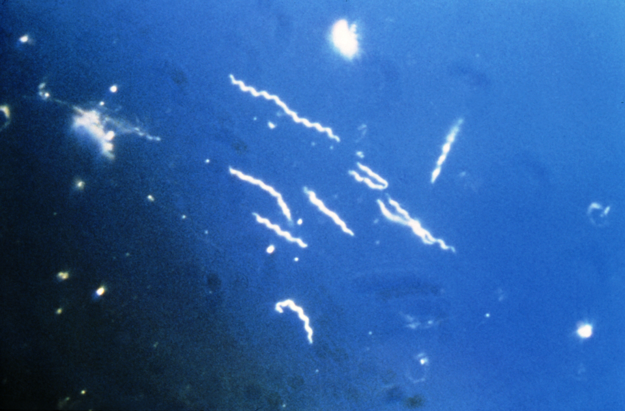

An image of the bacteria, Borrelia burgdorferi.

The associated Wikipedia page for this image is: https://en.wikipedia.org/wiki/Borrelia_burgdorferi.

# Part II

I created a plot from the data after reading the data in and summing the G and C columns to get GC content using ggplot, seen in the figure below.

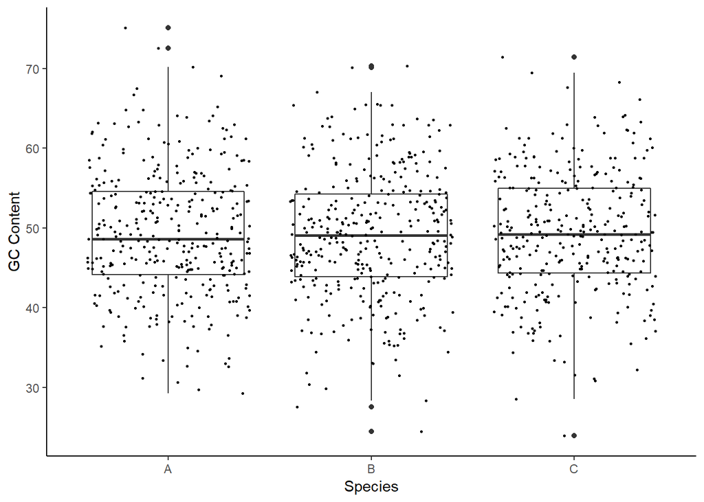

GC content for various sequences belonging to three separate species.

```r
# Read in the data
gc.dat <- read.csv("GC_content.csv")

# Get GC Content
gc.dat$GC <- gc.dat$G + gc.dat$C

# Order by species
gc.dat <- gc.dat[order(gc.dat$Species),]

library(ggplot2)

ggplot(aes(x=Species, y=GC), data=gc.dat) +
  geom_boxplot() +
  ylab("GC Content") +
  theme_classic() +
  geom_jitter(size=0.5)
```